# 0: Prelude No. 1 in R major

R for faculty, Fall 2024

Jonas Moss

## About the course

`R` is a big topic.

### Goal

- Be able to do *some* things in `R` and *figure out how to do more*.
- Gain some exposure to important programming ideas.

## Rough goals

1. Investigate objects, read documentation, and understand basic types.
2. Some *real programming* with loops and conditionals.
3. Load data, do some data manipulation.
4. Establish good habits.
5. Make some plots.
6. Fit some models, carry out some tests.
7. Some usage of `Quarto`, a technical publishing system could *can* write your papers in.

## What we won’t do (too much of)

- Get into the nitty gritty.
- Use precise computer science lingo.
- Be comprehensive about `R` and its package ecosystem.
- Do much “real programming”.
- Documentation and testing.
- Open science practices.
- Real use of `Quarto`.

All of these are, of course, important. And worth learning.

## About me

- Mathematical statistician, PhD 2020 at University of Oslo.
- Researching theoretical psychometrics, i.e., “measuring the mind”.
- Author of four published `R` packages.
- Programmed in `R` for $\approx$ 10 years, programmed for 20 years.
- Also programming in Rust, Python, and some C++ when needed.
- Value `R` for what it is; I’m not a super-enthusiast. (There are many!)
- I *do* enjoy programming for its own sake.

## What are your goals?

- Reproducible science?
- Calculating power in mixed effects models?
- Running structural equation models using `lavaan`?
- Nothing in particular?
- Just want to learn how to program?
- Graphs?
- Spontaneous data analysis?

## What you need

1. Install `R`, https://cloud.r-project.org/
2. Install `RStudio`, https://posit.co/download/rstudio-desktop/

## About `R`

- Created in 1995 as an open source descendant of `S` (1976).
- Maintained by the R Core Team.
- “Made by statisticians, for statisticians.”
- Very easy to do easy things, quite hard to do hard things. Brittle.
- Package manager called `CRAN`. Contains packages not made the R Core Team.
- Hated by software engineers. Good for getting things done.
- Popular, with an obscene amount of statistical packages.

## Running code

- Open RStudio and create a new **project** `rcourse`. (`File -> New project`).
- Projects are needed for organization and, crucially, the *working directory*.
- Paste the course files into the working directory.
- We will always use projects, and I strongly suggest you do so too.
- Make a new file `new.R` (CTRL+SHIFT+N).
  - Write the line `(.packages())`, save the file (CTRL+S).
  - Press CTRL+A to highlight all lines.
  - Press CTRL+ENTER to run the highlighted lines.
- Open `00-intro.qmd`. You can execute the code blocks using the “play” button.

# Overview

- This is an overview.
- We’ll cover most of this in more detail, so don’t worry if you don’t understand everything.

## Packages

The `.packages()` function returns all loaded packages. **Execute this.**

```r
(.packages())
```

```
[1] "stats"     "graphics"  "grDevices" "utils"     "datasets"  "methods"
[7] "base"
```

- These are the automatically loaded packages. Several other packages are included in the `R` installation.
- Look at the “package” tab in RStudio to see your installed packages.
- What functions do `stats` contain? (No one knows all functions in every base package.)
- In the *console*, type `stats::`. You should get a list of all *functions* (and more!) in the `stats` package along with some short documentation.

## Documentation

Find the long documentation as follows (run the code!):

```r
?PP.test
```

You can also write:

```r
?stats::PP.test()
```

## Installing packages

We will make use of the `datarium` package. Install it using

```r
install.packages("datarium")
```

This function installs packages from `CRAN` (“crane”, as in the bird), the official repository for `R` packages.

Find all data sets in the package using `datarium::` in the console.

```r
?datarium::anxiety
```

## Installing packages from Github

Many packages are not on `CRAN`. They are usually on *Github*.

```r
install.packages("remotes")
```

Let’s install `univariateML`, a package for univariate density estimation.

```r
remotes::install_github("JonasMoss/univariateML")
```

## Using installed packages

The *assigment operator* `<-` (or `=`) assigns a value to a *variable*.

```r
anxiety <- datarium::anxiety
head(anxiety)
```

```
  id group   t1   t2   t3
1  1  grp1 14.1 14.4 14.1
2  2  grp1 14.5 14.6 14.3
3  3  grp1 15.7 15.2 14.9
4  4  grp1 16.0 15.5 15.3
5  5  grp1 16.5 15.8 15.7
6  6  grp1 16.9 16.5 16.2
```

`anxiety` is *data frame*. Access its columns with `$`:

```r
anxiety$t1
```

```
 [1] 14.1 14.5 15.7 16.0 16.5 16.9 17.0 17.0 17.3 17.3 17.8 17.9 19.1 19.4 19.8
[16] 13.7 14.7 14.9 15.1 15.8 16.4 16.6 16.9 16.9 17.2 17.8 17.8 18.2 18.4 19.3
[31] 14.6 15.0 15.5 15.7 16.4 16.9 17.1 17.3 17.5 17.6 17.8 17.9 18.4 18.5 19.0
```

## Using installed packages

Access a function from an installed package using `::`.

```r
object <- univariateML::mlnorm(anxiety$t1)
```

```r
object
```

```
Maximum likelihood estimates for the Normal model
  mean      sd
16.916   1.472
```

Here the object is *printed*.

Or using `library`. You’ll often use this, but it’s often better to use `::`.

```r
library("univariateML")
object <- mlnorm(anxiety$t1)
object
```

```
Maximum likelihood estimates for the Normal model
  mean      sd
16.916   1.472
```

## Navigating a library

Again, use `univariateML::`. Some libraries have a help file directly available.

```r
?univariateML
```

## Plotting

In the documentation we see that `univariateML` supports plots. Let’s try it.

```r
plot(obj)
```

[output not shown]

[output not shown]

`plot` is a *generic function*, i.e., a function that may work in different ways depending on the arguments you supply it.

## More plotting

Plots can be added on top of each other using `lines`. More on this later.

```r
hist(anxiety$t1, freq = FALSE)
```

```r
lines(obj)
```

[output not shown]

[output not shown]

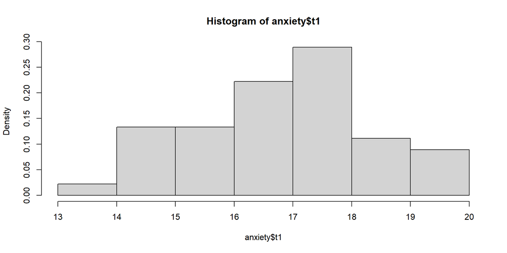

## Quarto

- We will use `.R` files and `.qmd` files.
- `qmd` files are *Quarto* files, a system for technical publishing.
- `qmd` files are split into text and program blocks. They can be compiled or “played”.
- You’re likely to use both, but most of our course will use `qmd` files because we will mix text and code liberally.

Try it out yourself. 1. Open this file in RStudio (`00-intro.qmd`) and press “Render”. 2. “Play” the first few code blocks.

## Summary

1. `R` is a programming language for statistics. Disliked by software engineers.
2. Use RStudio and the *projects* in RStudio.
3. `.R` files are scripts, containing only code; `.qmd` files contain text and code.
4. Investigate libraries using `::` in the console and use `?func` for help.
5. Install external packages with `install.packages` or `remotes::install_github`.
6. We’ll use Quarto files from now on; probably no pretty presentations!